# Chapter 6. Extending the ARMA model: Seasonality and trend

### Seasonal autoregressive moving average (SARMA) models

A general SARMA$(p,q)\times(P,Q)_{12}$ model for monthly data is
$$\phi(B)\Phi(B^{12}) (Y_n-\mu) = \psi(B)\Psi(B^{12}) \epsilon_n$$
where $\{\epsilon_n\}$ is a white noise process and
$$\begin{eqnarray*}
\mu &=& \mathbb{E}[Y_n]
\\
\phi(x)&=&1-\phi_1 x-\dots -\phi_px^p,
\\
\psi(x)&=&1+\psi_1 x+\dots +\psi_qx^q,
\\
\Phi(x)&=&1-\Phi_1 x-\dots -\Phi_Px^P,
\\
\Psi(x)&=&1+\Psi_1 x+\dots +\Psi_Qx^Q.
\end{eqnarray*}$$

Why do we assume a multiplicative structure？It adds simplicity and makes it easier to find roots. This is not necessarily related to being a good model for data.

SARMA model is a special case of an ARMA model, where the AR and MA polynomials are factored into a **monthly** polynomial in $B$ and an **annual** polynomial in $B^{12}$. For the SARMA$(p,q)\times(P,Q)_{d}$ model, $d$ is called the period.

```r
dat <- read.table(file="data/huron_depth.csv",sep=",",header=TRUE)
dat$year <- strtoi(substr(dat$Date, 7,10))
dat$month <- strtoi(substr(dat$Date, 1,2), base=10L)
head(dat,3)
```

```
##         Date Average year month
## 1 01/01/1860 177.285 1860     1
## 2 02/01/1860 177.339 1860     2
## 3 03/01/1860 177.349 1860     3
```

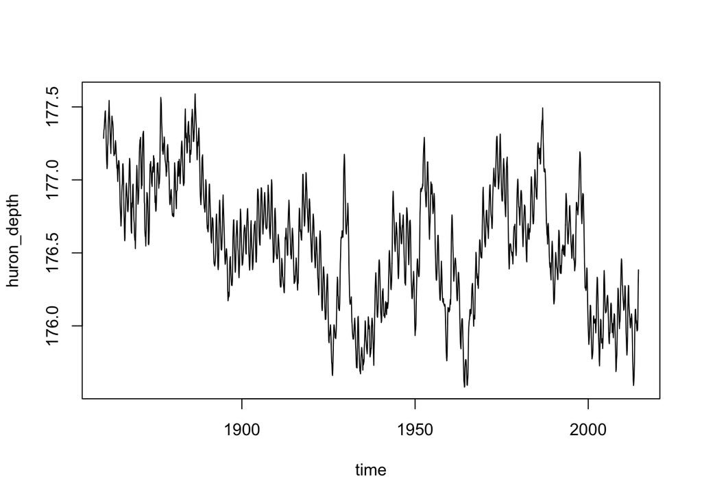

```r
huron_depth <- dat$Average
time <- dat$year + dat$month/12
# Note: we treat December 2011 as time 2012.0, etc
plot(huron_depth~time,type="l")
```

Based on our previous analysis, we’ll go with AR(1) for the annual polynomial. Let’s try ARMA(1,1) for the monthly part.Thus, we seek to fit the model
$$(1-\Phi_1 B^{12})(1-\phi_1 B) Y_n = (1+\psi_1 B)\epsilon_n.$$

```r
huron_sarma11x10 <- arima(huron_depth,
                          order=c(1,0,1),
                          seasonal=list(order=c(1,0,0),period=12)
                          )
huron_sarma11x10
```

```
##
## Call:
## arima(x = huron_depth, order = c(1, 0, 1), seasonal = list(order = c(1, 0, 0),
##     period = 12))
##
## Coefficients:
##          ar1     ma1    sar1  intercept
##       0.9641  0.3782  0.5104   176.5714
## s.e.  0.0063  0.0203  0.0218     0.0909
##
## sigma^2 estimated as 0.002592:  log likelihood = 2884.36,  aic = -5758.72
```

The residual analysis is similar to non-seasonal ARMA models. We look for residual correlations at lags corresonding to multiples of the period (in this specific cases, 12, 24, 36, …) for **misspecified annual dependence**.

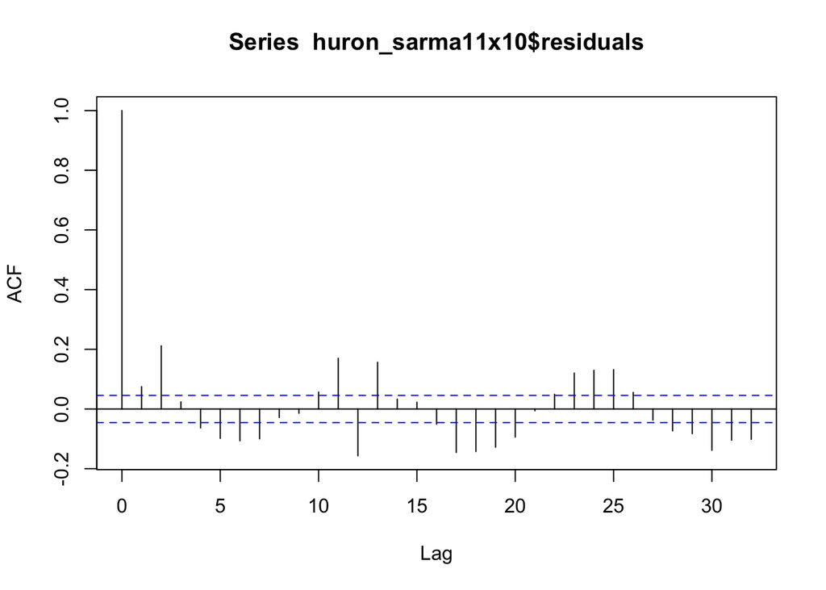

```r
acf(huron_sarma11x10$residuals)
```

According to the acf plot, perhaps we should try an extra seasonal term (looking at values of 12, 24, 36 with negative, positive and negative correlation respectively), e.g., (P,Q) = (1,1) instead of (1,0). The oscillatory component for within-year variation might suggest $p=2$ since $p=1$ can only give exponentially decaying acf.

### ARMA models for differenced data

Applying a difference operation to the data can make it look more stationary and therefore more appropriate for ARMA modeling. This can be viewed as a **transformation to stationarity**.

We can transform the data ${y_{1:N}}$ to ${z_{2:N}}$
$${z_n} = \Delta {y_n} = {y_n}-{y_{n-1}} = (1-B)y_n.$$

An ARMA$(p,q)$ model $Z_{2:N}$ for the differenced data ${z_{2:N}}$ is called an **integrated autoregressive moving average** model for ${y_{1:N}}$ and is written as ARIMA$(p,1,q)$. Formally, the ARIMA$(p,d,q)$ model with intercept $\mu$ for $Y_{1:N}$ is
$$\phi(B)\big( (1-B)^d Y_n-\mu \big) = \psi(B) \epsilon_n$$
However, it is unusual to fit an ARIMA model with d > 1.

### The SARIMA$(p, d, q) \times (P, D, Q)$ model

A general SARIMA$(p, d, q) \times (P, D, Q)$ model is defined as
$$\phi(B)\Phi(B^{12}) ( (1-B)^d(1-B^{12})^D Y_n-\mu ) = \psi(B)\Psi(B^{12}) \epsilon_n.$$

For example, the SARIMA$(0, 1, 1) \times (0, 1, 1)_{12}$ model has often been used for forecasting monthly time series in economics and business. It is sometimes called the **airline model**.

### Modeling trend with ARMA noise

A general signal plus noise model is
$$Y_n = \mu_n + \eta_n,$$
where $\{\eta_n\}$ is a stationary, mean zero **stochastic process**, and $\mu_n$ is the mean function. If $\eta_n\}$ is uncorrelated, it is a **signal plus white noise model**. Otherwise it can be referred to as a **signal plus colored noise model**. Signal and trend are used interchangeably.

When the mean function (also known as the trend) has a linear specification, the signal plus ARMA noise model is known as **linear regression with ARMA errors**.

### Setting up a formal hypothesis test

Available tests: Z tests on the coefficients, likelihood ratio tests.

Supplementary analysis: plot residuals. simulation study, bootstrap.